# Manuscript: administrative recognition of autism in Chile, 2019–2025

Article of the study (version 10, 14 September 2026), reproduced from the repository with its figures regenerated at render time

Published

September 14, 2026

Home Methods REM GRD Manuscript Supplement Corpus

**4**Panel figures regenerated by this page in 25 s (English and Spanish plates)

**2**Tables of the article

**51**Paragraphs (summary, research in context, introduction, methods, results, discussion and declarations)

**29**Verified references

This page reproduces the **article** of the study as printed by version 10 of the manuscript. The text, the numbered citations and the two tables come from `docs/lancet/data/contenido_v10.json`, exported by the document builder with every figure already resolved against the verified facts file. The four panel figures are **not copies**: each time this page is rendered, `docs/lancet/figuras_principales.py` rebuilds them from the public tables of `docs/lancet/data/` (copies of the tidy outputs and of the verified data of revision 10, plus a commune extract without identifiers), with the same code that produced the submitted plates. Every plate links to its 175 mm PNG (300 dpi), SVG and PDF files, in English; the Spanish plates and text are generated alongside and kept in the same folders.

Case definition: GRD episodes with an eligible F84 code, excluding Rett syndrome (F84.2); REM programmes with the strict autism code except where “F84 family” is indicated. All counts are administrative recognition, not prevalence or incidence. Statements in square brackets are decisions pending from the authors. The supplementary material reproduces the extended methods, the complementary results, tables S1–S9 and figures S1–S9; the extended corpus collects the plates and tables of the earlier versions of the study.

Layout check of the plates generated in this render (text outside the canvas and overlaps between labels must be zero)

| Figure | Language | Width (mm) | Height (mm) | Font sizes (pt) | Off-canvas texts | Overlaps |
| --- | --- | --- | --- | --- | --- | --- |
| Figure 1 | en | 175.0 | 215.0 | 6.4–11.0 | 0 | 0 |
| Figure 2 | en | 175.0 | 215.0 | 5.6–11.0 | 0 | 0 |
| Figure 3 | en | 175.0 | 172.0 | 5.8–11.0 | 0 | 0 |
| Figure 4 | en | 175.0 | 172.0 | 6.2–11.0 | 0 | 0 |
| Figure 1 | es | 175.0 | 215.0 | 6.4–11.0 | 0 | 0 |
| Figure 2 | es | 175.0 | 215.0 | 5.6–11.0 | 0 | 0 |
| Figure 3 | es | 175.0 | 172.0 | 5.8–11.0 | 0 | 0 |
| Figure 4 | es | 175.0 | 172.0 | 6.2–11.0 | 0 | 0 |

Amaru Agüero Jiménez; Patricia Soto Icaza

Centro de Investigación en Complejidad Social, Facultad de Gobierno, Universidad del Desarrollo

Correspondence to: Patricia Soto Icaza, patriciasoto@udd.cl (affiliation above). [Postal address and telephone to be completed.]

## Summary

Background. Autism counts in routine records are rising while coverage, coding and definitions change together. We examined recording across Chile's public health and education systems, 2019–2025, and whether growth survived fixed institutional participation and case definitions.

Methods. National multisource study of unlinked routine records: public hospital episodes (2019–2024), mental-health programme entries, December follow-up stocks and harmonised school-support registrations to 2025. The main outcome was eligible episodes per 100 000 hospital episodes of the same panel and year. Robustness used continuously reporting panels, diagnostic position and coding-depth strata, and burden and repeat contact were also described.

Findings. Eligible hospital episodes rose from 2334 to 8731 and the indicator from 202·7 to 804·1 (95% confidence interval 787·3–821·1) per 100 000 episodes; other F80–F89 categories rose less or not at all. In 2024, 8341 of 8731 (95·5%) carried the code only secondarily, and growth persisted within every coding-depth stratum. In 2021–24, 19·1% of identifiers accounted for 40·7% of eligible episodes. Programme entries rose from 2085 (2021) to 13 155 (2025), December follow-up stocks from 3853 to 29 974, and school registrations from 21 012 to 106 786.

Interpretation. Autism is documented throughout general hospital care, not in one specialty service, and a small minority of people generated much of the recorded workload. Health systems should prepare general hospital and primary care, count people as well as episodes, and publish the unit, denominator and coverage of each indicator. These series do not measure prevalence.

Funding. To be completed by the authors.

## Research in context

### Evidence before this study

We searched PubMed and Crossref on Sept 10, 2026, without date or language limits, combining terms for autism (autism, autism spectrum disorder), routine data (administrative records, registry, diagnosis trends) and setting (Chile, Latin America), and screened the reference lists of the studies retrieved and the official documentation of each data source. National register studies from the UK, Denmark and Sweden consistently report rising recorded autism diagnoses and show that reporting rules and diagnostic practice shape those trends; they are methodologically strong, but describe high-income settings with individually linkable registers. Latin American evidence is sparser and mostly cross-sectional. We identified no study that followed several independent national administrative systems over consecutive years, or that examined whether recorded growth persists when institutional participation, diagnostic position and coding depth are held fixed.

### Added value of this study

To our knowledge, this is the first study to follow autism recording simultaneously through hospital episodes, mental-health programme entries, follow-up registers and school support in a Latin American country, and to submit each series to the same robustness tests. The rise in hospital recording is not an artefact of more hospitals reporting or of longer diagnosis lists: it persists in the 65 hospitals present in every year and within every coding-depth stratum. Autism was recorded only in secondary positions in 95·5% of eligible episodes in 2024, across psychiatric, neurological, respiratory and surgical admissions. Reporting the number of contributing institutions beside every count also makes contractions visible.

### Implications of all the available evidence

Autistic people are already reaching Chilean hospitals, primary care and schools in numbers several times larger than six years earlier, and general services are where they are seen. Health systems that plan autism care from routine records can prepare general hospital and primary-care teams rather than specialist services alone, and publish the unit, denominator, case definition and number of reporting institutions with every indicator, so that growth in recognition can be told apart from growth in need. Neither these series nor the available surveys establish population prevalence.

## Introduction

Autistic people have diverse health, educational and support needs across the life course. Published syntheses place global prevalence near 1 in 100, with a median of 100 per 10 000 and a median male-to-female ratio of 4·2;<sup>1</sup> a three-level meta-analysis applying stricter ascertainment criteria pooled a lower figure, close to 0·7%,<sup>2</sup> and the Global Burden of Disease Study 2021 estimated 61·8 million autistic people worldwide, 1 in 127, with an age-standardised prevalence of 788 per 100 000.<sup>3</sup> Much of the measured rise of recent decades is attributed to broader diagnostic criteria, greater awareness and the capacity of health and education systems to identify the condition, rather than to a change in occurrence. Chile has no comparable national estimate, so planning depends on what its institutions record. The Lancet Commission on the future of care and clinical research in autism emphasises coordination across health, education and social support, alongside heterogeneity in individual needs;<sup>4</sup> in Latin America, caregiver studies describe diagnostic delay and barriers to service access.<sup>5,6</sup>

Routine records can reveal how institutions encounter and document autism, but interpreting their growth requires attention to what is counted. A diagnosis recorded during an episode, an entry to a programme, a person registered under follow-up at a particular date, and a student receiving educational support represent different events or states. They are affected by diagnostic definitions, opportunities for service contact, and administrative coverage. Changes in these records can matter for planning even when they do not identify a change in population prevalence. International registry studies have documented substantial changes in recorded autism diagnoses and have shown that measurement and reporting practices can influence those trends.<sup>7–9</sup>

Chile provides an opportunity to study this problem across several public administrative systems. Hospital diagnosis-related-group files (GRD), Monthly Statistical Summaries (REM), and the School Integration Programme (PIE) document different aspects of institutional recording. National surveys ask about reported autism in distinct age groups. Chilean studies include an urban childhood prevalence study and a national school-registry analysis linked to regional health records, while regional caregiver research describes diagnostic delay and access barriers.<sup>5,10,11</sup> The existence of these sources does not make them interchangeable. Their different coverage, units, historical categories, and geographical assignments are part of the scientific question.

The period from 2019 to 2025 included disruption and recovery of service activity, changes in diagnostic reporting, and the introduction of Law 21.545 in 2023.<sup>12</sup> An increase in counts during this period cannot itself identify the effect of any one of these changes. We asked how administrative recording of autism changed in Chile, how robust hospital and outpatient trends were to institutional coverage, coding depth, and definition, and what complementary patterns appeared across services and territories. We centred the analysis on GRD episodes relative to hospital activity, used mental-health entries from module A05 and child/adolescent special-health-needs follow-up from module P2 as complementary indicators, and evaluated education and survey data within their own definitions. We treated territorial analyses as secondary and exploratory.

## Methods

### Design and sources

We conducted a national descriptive study of unlinked administrative series in Chile. GRD public-hospital episodes covered 2019–2024; REM modules contributed definition-specific periods through 2025. PIE supplied educational triangulation, and the National Disability and Dependency Survey (ENDIDE) 2022 and the National Quality of Life and Health Survey (ENCAVI) 2023–2024 supplied external population context. Supplementary figure S1 shows parallel data processing; table S1 details sources and eligibility. A written analysis plan is available from the authors; the study was not prospectively registered. Reporting followed Strengthening the Reporting of Observational Studies in Epidemiology (STROBE) and REporting of studies Conducted using Observational Routinely-collected health Data (RECORD).<sup>13,14</sup>

The unit in GRD was an episode, including hospitalisation and major ambulatory surgery, with up to 35 diagnostic positions. The primary indicator was eligible episodes per 100 000 episodes in the same year, hospital panel, and activity category.<sup>15</sup> We separately described principal diagnosis, exclusively secondary diagnosis, strict hospitalisation, and major ambulatory surgery. Within-year identifier counts were supplementary descriptions; identifiers were not used to follow individuals across years, particularly across the format change between 2020 and 2021. Department of Health Statistics and Information (DEIS) discharges were used only as a principal-diagnosis comparison with their own discharge denominator and differing coverage.<sup>16</sup>

For clinical context, principal non-F84 categories were described among secondary-only eligible episodes, and non-F84 chapters across eligible episodes. Repeated codes within an episode were deduplicated; chapter groups could overlap. We retained the ten most frequent 2024 categories in both endpoint years (table S9). Hospital plots suppress institutions with fewer than five eligible episodes; their rates and ranks are withheld. Length of stay used episodes with valid admission and discharge dates and is reported unadjusted beside all hospitalisation episodes of the same panel and year; case mix used the relative weight of the assigned diagnosis-related group. Readmission counted any further admission within 30 days of an eligible discharge, and repeat contact counted episodes per valid identifier within the 2021–2024 era alone, because identifiers are not linked across the 2020–2021 format change.

### Definitions and reporting panels

F84, pervasive developmental disorders, is a category of the disorders of psychological development block (F80–F89) within chapter V of the International Classification of Diseases, tenth revision (ICD-10), mental and behavioural disorders. Eligible hospital codes were F84 at category level and the subcodes for childhood autism (F84.0), atypical autism (F84.1), other childhood disintegrative disorder (F84.3), overactive disorder associated with intellectual disability and stereotyped movements (F84.4), Asperger syndrome (F84.5), other pervasive developmental disorders (F84.8) and pervasive developmental disorder, unspecified (F84.9). Rett syndrome (F84.2) was never an eligible code. An episode remained eligible if another selected code coexisted with F84.2; principal eligibility was determined from the principal field alone. The full F84 family and F84.0 alone were sensitivity definitions. The stable hospital panel comprised the 65 hospitals present throughout the six years. Coding depth was the number of non-empty diagnosis positions and was examined within strata as well as in selected models. None of these restrictions was interpreted as clinical validation or causal adjustment. For comparison we tabulated the remaining three-character categories of the same block (F80, F81, F82, F83, F88 and F89) across all episodes of the same panels and years, in any diagnostic position, with the same code normalisation and the same episode denominator; an episode carrying two categories contributes to both, so the categories are not mutually exclusive.

REM A05 strict-autism entries used code 05990022 from 2021; the broader diagnostic family was kept separate, including in territorial analyses. P2 used code P2500500 at the December cut in 2019–2025, with a verified expansion from ages 0–9 to 0–19 in 2021; the two age-definition eras were kept separate. P6 (REM mental-health follow-up module) strict-autism stocks used P6241010 for primary care and P6241060 for specialty care from 2021. A05 and A28 (REM rehabilitation module) were flows; P2 and P6 were cut-specific stocks, never summed across cuts. A03 (REM assessment-scale module) screening and A27 (REM health-education module) assisted referrals were described by code and definition era.<sup>17</sup> Stable REM panels required presence of the selected code in every eligible year, using the selected cut for series P. Numeric zero, a present row with an empty value, an absent row, and an establishment not observed reporting that code were recorded as distinct states. Annual presence was not interpreted as monthly completeness.

### Population and educational context

Resident-denominator indicators used National Statistics Institute (INE) population projections based on the 2017 census; they were supplementary to hospital activity indicators.<sup>18</sup> Dividing records from the public network by residents does not define a population covered by those services. ENDIDE and ENCAVI estimates used their published weights, strata, and primary sampling units, with domain estimation and design-based uncertainty.<sup>19,20</sup> We distinguished eligible samples, valid responses, and positive responses. PIE autism and autism spectrum disorder (ASD)–Asperger categories were harmonised for 2019–2023 and combined with the later report of the National Higher Education Quality Assurance System (SINACES), documenting the source change and the 2022 discrepancy.<sup>21,22</sup> National Board of School Assistance and Scholarships (JUNAEB) results were not used for any estimate because outcome coding, denominator interpretation, and incomplete survey-design information limit comparability.

For survey estimation, subgroup membership entered the numerator and denominator of a weighted ratio while the full survey design was retained for variance estimation. Logit-transformed intervals used the design degrees of freedom. Missing diagnostic responses were excluded from the relevant response denominator and examined in explicit sensitivities, rather than silently recoded as negative. The physician-confirmation estimate among all ENDIDE children and the conditional proportion among children whose caregiver reported autism answer different questions and were kept separate. In administrative age–sex summaries, source marginal totals were retained; small discrepancies between age cells, sex totals, and the published aggregate were documented rather than forced to agree. Recorded sex was analysed as supplied by each source. Survey domains with fewer than 30 positive responses or relative standard error above 30% were flagged for limited precision.

### Statistical and territorial analysis

We reported observed counts and indicators before model summaries. Hospital and resident-denominator indicators used exact Poisson 95% intervals; age-standardised indicators used World Health Organization (WHO) standard weights and gamma intervals.<sup>23,24</sup> These intervals describe the specified counting model, not uncertainty from incomplete administrative coverage. Selected log-linear quasi-Poisson models used a log denominator offset and Pearson dispersion; annual percent change was 100(exp(β)−1), with Wald intervals.<sup>25</sup> Hospital-year models used hospital fixed effects, with hospital-clustered standard errors in a selected sensitivity. Annual models with few observations, particularly those with additional covariates, were treated as descriptive and their non-positive results retained. Ratios of male to female counts used binomial-based intervals; indices divided each observed series by its own 2021 value, without extrapolation.

The secondary spatial analysis used GRD commune of residence, indirect age–sex standardisation, empirical-Bayes smoothing and population-weighted concentration measures, with explicit spatial weights, permutation procedures and false-discovery-rate control; Spearman coefficients were descriptive and were not presented as accounting for spatial dependence. Its full specification, sensitivities and results are in appendix methods A11 and the accompanying figures and tables.

## Results

### Hospital recording: magnitude, robustness and who is recorded

The observed GRD panel contained 65 hospitals in each year from 2019 to 2022, 68 in 2023 and 72 in 2024; all 65 original hospitals remained in the final year. Episodes with an eligible code in any diagnostic position increased from 2 334 among 1 151 475 episodes in 2019 to 8 731 among 1 085 813 in 2024, and the indicator from 202·7 (95% confidence interval [CI] 194·6–211·1) to 804·1 (787·3–821·1) per 100 000 GRD episodes, a 3·97-fold difference (table 1; figure 1a). The stable 65-hospital panel tracked the observed panel closely (808·6 per 100 000 episodes in 2024). Divided by the resident population and standardised to the WHO world age structure, eligible episodes rose from 15·8 (95% CI 15·2–16·5) to 59·3 (58·1–60·6) per 100 000 residents, and strict-autism programme entries from 14·3 (13·7–14·9) per 100 000 residents in 2021 to 90·2 (88·7–91·8) in 2025 (figure 1b). These are record indicators, not prevalence estimates.

Quasi-Poisson models summarised the observed indicator with an annual percent change of 35·9% (95% CI 30·0–42·1), with similar estimates for the stable panel, for 2021–2024 alone and for strict hospitalisation (figure 1c; table S2). Mean coding depth increased from 4·39 to 5·78 diagnoses per episode, yet the indicator rose within every coding-depth stratum, between 3·6-fold and 5·0-fold among episodes with three to ten diagnoses, and the depth-adjusted model gave 46·9% (40·8–53·3) (figure S2a). Robustness was not uniform: the principal-diagnosis indicator rose more modestly, from 19·8 (95% CI 17·3–22·5) to 35·9 (32·4–39·7) per 100 000 episodes, and the specification that included both coding depth and the 2020–2021 indicator gave −2·4% (−20·1 to 19·2) with two residual degrees of freedom; this imprecise, non-positive estimate is retained (figure S8b). The increase was also specific to autism within its diagnostic block: on the same denominator, mixed specific developmental disorders (F83) rose 3·35-fold, disorders of scholastic skills (F81) 1·80-fold and speech and language disorders (F80) 1·78-fold, while F82 and F89 were unchanged, against 3·97-fold for autism (figure 1d). The independent DEIS discharge series moved in the same direction (figure S2d), and hospital heterogeneity remained substantial: among 72 hospitals in 2024 the median indicator was 638·0 per 100 000 episodes (interquartile range 393·3–976·1; maximum 5 210·7; figure S2c).

Growth was faster among females than males. The male-to-female ratio of eligible episodes fell from 3·27 (95% CI 2·97–3·60) in 2019 to 2·03 (1·94–2·13) in 2024, and the ratio of strict-autism programme entries from 3·52 (3·17–3·92) in 2021 to 2·07 (1·99–2·14) in 2025 (figure 1e); age-standardised episode indicators rose from 23·8 to 79·0 per 100 000 male residents and from 7·6 to 39·0 per 100 000 female residents, with annual changes of 37·5% (33·6–41·5) and 54·9% (48·3–61·8) (figure S3). Recording remained concentrated in childhood and adolescence, with a growing adolescent and adult share: in 2024, 47·7% of the 8 728 episodes with known age involved children aged 0–9 years, 40·8% those aged 10–19 years and 11·5% adults, against 55·7%, 33·2% and 11·1% in 2019. Resident-denominated episode indicators rose in every age group, by 143% at ages 0–4 years, 420% at 15–19 years and 362% at 20–24 years (figure 1f), and episodes at age 20 years or older rose from 260 to 1 004. Programme entries shifted likewise, with adult A05 entries rising from 121 to 1 205 (table S7).

### Clinical profile of the hospital episodes

Autism was recorded overwhelmingly as an accompanying condition rather than as the reason for admission: 2 106 of 2 334 eligible episodes (90·2%) carried the code only in a secondary position in 2019 and 8 341 of 8 731 (95·5%) in 2024 (figure 2a). Among these secondary-only episodes in 2024, the most frequent principal three-character categories were depressive episode (380, 4·6%), redundant prepuce, phimosis or paraphimosis (373, 4·5%), epilepsy (358, 4·3%) and acute appendicitis (324, 3·9%); no category reached 5%. Their composition changed: depressive episodes rose from 22 of 2 106 (1·0%) to 380 of 8 341 (4·6%), whereas epilepsy rose in count, from 152 to 358, but fell in share from 7·2% to 4·3% (figure 2b; table S9). Non-F84 mental and behavioural chapters rose from 25·4% to 40·6% of eligible episodes and respiratory chapters from 26·2% to 34·6%, while nervous-system chapters fell from 26·1% to 17·9% despite increasing from 609 to 1 566 episodes (figure S9a).

Eligible episodes also became less distinctive from the rest of hospital activity. Among hospitalisation episodes, mean length of stay fell from 9·4 days in 2019 to 7·7 in 2024 while the mean for all hospitalisation episodes in the same panel rose from 6·7 to 7·1, and the mean relative weight of the diagnosis-related group fell from 0·84 to 0·81 (figure 2c). Episodes with autism as principal diagnosis stayed longer, 16·1 days in 2019 and 13·4 in 2024, than secondary-only episodes, 8·6 and 7·3 days (figure S9b), unstandardised for age, case mix or hospital. Recorded contact was repeated and concentrated: within 30 days of an eligible discharge, 15·1% (95% CI 13·7–16·6) were followed by an all-cause readmission in 2019 and 12·7% (12·0–13·4) in 2024, and 21·9% (20·3–23·6) and 19·6% (18·6–20·6) within 90 days; most readmissions again carried an eligible code (10·3% of discharges at 30 days in 2024). In the validated identifier era 2021–2024, 15 670 identifiers accounted for 21 374 eligible episodes: 19·1% of identifiers accounted for 40·7% of episodes, and the 189 identifiers with six or more episodes (1·2%) for 1 852 episodes (8·7%) (figure 2d). Identifiers are not linked across the 2020–2021 format change, so these describe contact within one era.

### The community care pathway and the period of Law 21.545

Primary-care screening records expanded with the 2023 introduction of Modified Checklist for Autism in Toddlers, Revised with Follow-Up (M-CHAT-R/F) codes. First-stage results rose from 19 632 in 2023 to 25 074 in 2024 (low risk 14 083 to 18 142; medium risk 3 642 to 4 698; high risk 1 907 to 2 234), high-risk results with specialist referral from 1 152 to 1 741, second-stage referrals from 1 136 to 2 283, and suspected autism identified in other consultations from 8 221 to 12 281 (figure 3a). These aggregated items are annual flows from different establishments; they cannot be linked into an individual cascade or converted into positivity or referral completion (figure S4c; table S4B).

Strict-autism A05 programme entries increased from 2 085 in 2021 to 4 640 in 2022, 8 049 in 2023, 11 842 in 2024 and 13 155 in 2025, while clinical discharges rose from 494 to 3 367 (figure 3b; table 2). Within 258 establishments with an eligible row every year, entries increased from 1 522 to 6 767, a 4·45-fold change against 6·31-fold in the observed network (figure S4a). People under control in December rose from 2 257 to 21 843 in primary care and from 3 562 to 12 645 in specialty care (figure 3c), with annual changes of 41·7% (95% CI 35·4–48·3) and 21·9% (18·4–25·5). P2 follow-up of autism among children with special health-care needs, whose age universe widened from younger than 10 years to younger than 20 years in 2021, rose from 3 853 to 29 974 within the latter era and from 1 748 to 9 128 in the same 193 establishments (figure S4b). Rehabilitation entries, first recorded in 2023, rose from 3 962 to 15 859 at the primary level and from 731 to 1 740 at the hospital level, whereas counselling and assisted referral in the screening context peaked in 2024 (3 874 and 1 068) and fell in 2025 (3 026 and 878) (figure 3d).

Law 21.545, published in March 2023, is a documented change in the institutional environment rather than an intervention that this design can evaluate. The new screening codes, the 2024–2025 redesign of the M-CHAT-R/F items and the rehabilitation entry codes entered the REM during its implementation (figure S4c), and every programme indicator continued to rise through 2025. The relative growth nevertheless decelerated as the period advanced: entries rose by 123%, 73%, 47% and 11% in successive years from 2022 to 2025, and the P2 December stock by 106%, 66%, 65% and 38%. Without a counterfactual these series neither support nor exclude an effect of the law; they show that recording expanded before its publication and that the pace of expansion slowed while it was being implemented.

### Convergence across systems and population context

Educational recording rose faster than the School Integration Programme as a whole. Harmonised autism registrations increased from 21 012 in 2019 to 63 642 in 2023 while total PIE enrolment grew from 385 995 to 473 006, so the autism share rose from 5·44% to 13·45%; the harmonised series reached 106 786 in 2025 (figure 4a; table S5). With 2021 as 100, GRD episode indicators reached 278 in 2024, DEIS principal-diagnosis discharges 200, A05 entries 568 (631 in 2025), the P2 December stock 564 (778), primary-care follow-up 706 (968) and PIE registrations 280 (346); equal indices do not imply equal levels or coverage (figure 4b).

Two national surveys provide population context that administrative series cannot supply. ENDIDE 2022 estimated reported autism at 2·87% (95% CI 2·37–3·47) among children aged 2–17 years, 4·57% among boys and 1·11% among girls, and 0·29% (0·22–0·38) among adults; the child estimate requiring reported physician confirmation was 2·39% (1·94–2·95). ENCAVI 2023–2024 estimated a diagnosis in 0·71% (0·50–1·01) of people aged 15 years or older (figure 4c; table S3). The surveys differ from each other, and from the administrative series, in question wording, age universe, respondent and denominator; they are not used to validate records, and no share of autistic people reaching services is estimated from them.

Hospital recording became geographically less concentrated: communes with eligible records increased from 242 to 302 of 346 between 2019 and 2024, and the population-weighted Gini coefficient declined from 0·373 to 0·299 (figure S6). Across communes in the common 2021–2024 window, hospital episode and programme entry indicators were only weakly aligned (Spearman ρ = 0·34 in 157 communes, and 0·24 when the Metropolitan Region was excluded), and the P2 stock aligned weakly with both (ρ = 0·11 and 0·32) (figure 4d; figure S7; table S6). These descriptive coefficients carry no spatial inference.

## Discussion

Autism recording expanded substantially and simultaneously across Chile's hospital, outpatient, follow-up and school-support records between 2019 and 2025. Hospital episodes carrying an eligible code rose almost fourfold relative to hospital activity, and the 2024 indicator in the 65 hospitals that reported in every year matched the indicator in the observed network, so the increase is not explained by hospitals joining the system. Mental-health programme entries rose 4·45-fold and December follow-up stocks more than fivefold within establishments that reported continuously and within a single age-definition era, and school registrations rose about fivefold. What these series measure is administrative recognition and recorded demand; they do not quantify how much of the change comes from reporting, diagnosis, coding, service use, or the underlying population. Recorded episodes also became shorter and less complex, and a small minority of people accounted for a large share of them. The increase was also concentrated in the most specific diagnostic code rather than in unspecified ones.

The predominance of secondary hospital coding places the increase within general health care. Principal diagnoses included psychiatric, neurological, respiratory and surgical categories, with no single category dominating. This diversity matters for planning because autistic patients can require care throughout the hospital, beyond services organised around autism as a principal diagnosis. Recorded co-diagnoses are nevertheless shaped by clinical contact and documentation. Their frequencies cannot establish excess comorbidity risk, severity or unmet need without a comparison population and clinical assessment. Repeated episodes contribute to workload but do not represent new diagnoses.

The clinical profile of a recorded episode changed as recording expanded. Eligible hospitalisations lasted almost three days longer than the average hospitalisation in 2019 and barely longer than it in 2024, and the mean relative weight of their diagnosis-related group fell over the same period. The simplest reading is that the episodes being captured moved from the most complex towards the ordinary, which is what broader recognition would produce. It is not the only reading: case mix, age structure, admission thresholds during the pandemic and coding practice all changed at once, and we did not standardise for them. The concentration of repeat contact is less exposed to those explanations, because it is internal to the recorded population. One in five identifiers accounted for two in five episodes, and 189 people accounted for 8·7% of all eligible episodes over four years. Service planning that counts episodes will therefore overstate the number of people to be served, and planning that counts people will understate the workload; both figures are needed, and only the second is usually published. The distinction between the national hospital indicator and the distribution of hospital indicators also matters for interpretation. The national value weights hospitals by their total activity; the median summarises the hospital distribution with equal weight for each institution. Their difference does not identify inadequate care or excess autism risk. Hospitals differ in referral roles, the ages and conditions treated, and documentation practices. The displayed variation therefore motivates examination of local service context before allocating resources according to a national average. Stable-panel agreement establishes neither comparable capture across hospitals nor uniform capacity within them (figure S2ca).

Three features of the data make reporting artefact an insufficient explanation, without making it irrelevant. First, growth persisted within coding-depth strata. Iezzoni and colleagues showed that additional diagnosis fields alone do not ensure complete comorbidity capture; Song and colleagues found that recorded diagnoses varied with local practice intensity.<sup>26,27</sup> Depth also reflects clinical complexity and hospital organisation, so stratification changes the episodes compared. Second, growth persisted within establishments that reported in every year, although stable panels answer a narrower question than complete service coverage: an establishment can contribute an annual row while lacking records in other months, and can change its catchment, staffing, coding and reporting intensity, while a missing row need not mean that no care occurred. Follow-up stocks additionally depend on entry, exit, transfer and retention, and must be read as the number recorded at each cut, with no observed individual transition between modules. Third, restriction to a single age-definition era and to known cells for children younger than 10 years retained an increasing follow-up trajectory within recurring establishments, although neither sensitivity resolves empty age cells or changes in follow-up practice. None of these comparisons is a causal decomposition. With six annual observations, adjustment for mean coding depth and the 2020–2021 disruption cannot recover a counterfactual without changes in coding, and the imprecise, non-positive principal-diagnosis sensitivity limits a uniform-growth narrative. The administrative picture also contains contractions, with fewer mental-health reporting establishments and fewer assisted referrals in 2025, so entries, stocks and reporting coverage are more informative monitored together than as a single aggregate growth estimate.

The time pattern does not show a discontinuity aligned with the 2023 law. Year-on-year growth in strict-autism programme entries was 123% in 2022, 73% in 2023, 47% in 2024 and 11% in 2025, and December follow-up stocks grew by 106%, 66%, 65% and 38% across the same years; educational registrations grew fastest between 2022 and 2023 and more slowly in each later year. Growth decelerated as the policy period advanced. This description neither supports nor excludes an effect of Law 21.545: the series are short, pandemic recovery overlaps the policy period, REM definitions changed within it, and no comparison group is available. We report the pattern because a reader will look for it, not because this design can attribute it.

The changing sex composition warrants attention because administrative recognition is age dependent. Loomes and colleagues found lower male predominance in studies that actively screened populations than in those restricted to existing diagnoses.<sup>28</sup> More recently, Swedish longitudinal records showed later diagnostic peaks among females and sex ratios that varied with age and period.<sup>29</sup> These findings support examining age alongside sex in Chilean surveillance; they do not establish that our declining record ratio measures a change in the population sex ratio. Age-specific profiles and clinical context add different information to surveillance: the former locate recorded demand along the life course, whereas the latter describe the contacts in which an eligible code is documented. Their joint presentation supports planning across paediatric, adolescent and adult services without implying that the same individuals moved between those services. Neither the age shift nor changing diagnostic proportions can distinguish changes in recognition from changes in underlying morbidity.

The contribution relative to earlier Chilean evidence is therefore specific. Roman-Urrestarazu and colleagues linked the 2021 national school registry with clinical records from Araucanía Sur and used Bayesian modelling to estimate national autism prevalence and unmet special-education needs.<sup>11</sup> Their study already brought education and health together. Our study addresses change over successive years, with hospital activity as the primary denominator and explicit hospital and establishment panels, diagnostic-position restrictions, coding-depth comparisons, and REM definition eras. We do not reproduce their linked design or infer prevalence from concordant trends. The two approaches answer different questions: the estimated population burden and educational support gap, versus the evolution and interpretability of routine recording. International studies show why these distinctions matter. United Kingdom primary-care data documented increasing recorded diagnoses, with different changes by age and sex; Danish analyses examined identifiable changes in diagnostic and reporting rules; and Swedish data distinguished changes in registered diagnosis from changes in the measured autism phenotype.<sup>7–9</sup> These results make changes in recognition and recording plausible explanations, but their effect sizes cannot be transferred to Chile. Education and surveys situate these service records within broader institutional and population contexts. The growing autism share within PIE cannot be described solely by expansion of overall programme enrolment, although historical categories and the source transition remain relevant. These sources provide neither clinical validation of hospital codes nor a multiplier for unrecorded service need.

Several limitations remain unresolved by sensitivity analysis. Neither GRD nor REM supplies a nationally validated population at risk for autism ascertainment. Public-network records omit activity outside the included systems and can include repeated contacts. No clinical validation of the eligible codes was undertaken. Pandemic-related changes coincide with evolving coverage, coding, and policy, and the final REM year has fewer A05 reporting establishments despite national presence in every month. Stable panels are selected institutional subsets rather than representative samples. The short time series make adjusted slopes sensitive to specification; conventional intervals address model uncertainty and not the full uncertainty of coverage, measurement, or dependence. The study was not prospectively registered. The territorial analyses reported in the appendix carry further limitations: GRD is assigned by recorded residence and REM to the establishment, and referral patterns, the concentration of specialist services and shared denominators can all affect ecological associations.

A six-country caregiver study reported mean ages of 22·4 months at first concerns and 46·3 months at diagnosis, placing expanding records within a potentially prolonged process of recognition and access.<sup>5</sup> The Lancet Commission emphasises diverse needs across the life course and coordination between health, education and social services.<sup>4</sup> For planning, these priorities favour tracking recorded workload together with age, support needs and service continuity, rather than treating an administrative total as a sufficient measure of care. Surveillance should therefore publish definitions, denominators and reporting coverage alongside workload, using age and service setting to guide capacity assessment. Law 21.545 provides policy context, but this design does not estimate its effect.<sup>12</sup> For health systems in the Americas that plan autism care from routine records, the practical implication is immediate: prepare general hospital and primary-care teams rather than specialist services alone, and publish the unit, denominator, case definition and number of reporting institutions with every count. Clinical code validation, repeated population measurement and ethically governed linkage would then help distinguish recognition, repeated use, continuity of care and unmet need.

### Contributors

AAJ and PSI [conceived and designed the study]. AAJ [assembled the source data, wrote the analysis code and did the analyses]. AAJ and PSI [interpreted the findings]. AAJ [wrote the first draft] and PSI [critically revised the manuscript for important intellectual content]. [AAJ and PSI] directly accessed and verified the underlying data. Both authors had full access to all data in the study, approved the final version, and accept responsibility for the decision to submit for publication.

### Declaration of interests

[We declare no competing interests.]

### Funding and role of the funding source

[Funding source and grant number, and the funder’s role in study design, data collection, analysis, interpretation and report writing, to be stated by the authors.] The corresponding author had full access to all data in the study and had final responsibility for the decision to submit for publication.

### Ethics

[Review body, approval or exemption reference, and date.] The study analysed de-identified administrative records and publicly released survey microdata, and no individual was contacted or identified; public availability of a dataset was not treated as evidence of exemption.

### Data sharing

All data analysed in this study are routinely collected records released by Chilean public agencies; appendix table S1 lists each source, the version used, the selected codes and the eligibility rules, so that every series can be reconstructed from the original releases. The analysis code and the derived tables underlying every figure and table [will be deposited at (repository and persistent identifier) on publication / are available from the corresponding author on reasonable request]. Commune-level files contain small cells and will be shared only in aggregated form after disclosure review.

### Use of artificial intelligence

Generative artificial-intelligence assistants (OpenAI Codex; Anthropic Claude) were used during 2026 for code review, bounded numerical checks and recalculations, figure adaptation, drafting, translation between English and Spanish, and assembly of the manuscript files. No tool was used to generate data, results or references. [The authors reviewed and verified all assisted content against the source outputs.] The authors take full responsibility for the integrity and accuracy of the work; no artificial-intelligence tool meets authorship criteria and none is listed as an author.

## References

1. Zeidan J, Fombonne E, Scorah J, et al. Global prevalence of autism: a systematic review update. Autism Res 2022; 15: 778–790.
2. Talantseva OI, Romanova RS, Shurdova EM, et al. The global prevalence of autism spectrum disorder: a three-level meta-analysis. Front Psychiatry 2023; 14: 1071181.
3. Santomauro DF, Erskine HE, Mantilla Herrera AM, et al. The global epidemiology and health burden of the autism spectrum: findings from the Global Burden of Disease Study 2021. Lancet Psychiatry 2025; 12: 111–121.
4. Lord C, Charman T, Havdahl A, et al. The Lancet Commission on the future of care and clinical research in autism. Lancet 2022; 399: 271–334.
5. Montiel-Nava C, Montenegro MC, Ramirez AC, et al. Age of autism diagnosis in Latin American and Caribbean countries. Autism 2024; 28: 58–72.
6. García R, Irarrázaval M, López I, et al. Encuesta para Cuidadores de Personas del Espectro Autista en Chile. Acceso a Servicios de Salud y Educación, Satisfacción, Calidad de Vida y Estigma. Andes Pediatr 2022; 93: 351–360.
7. Russell G, Stapley S, Newlove-Delgado T, et al. Time trends in autism diagnosis over 20 years: a UK population-based cohort study. J Child Psychol Psychiatry 2022; 63: 674–682.
8. Hansen SN, Schendel DE, Parner ET. Explaining the Increase in the Prevalence of Autism Spectrum Disorders: The Proportion Attributable to Changes in Reporting Practices. JAMA Pediatr 2015; 169: 56–62.
9. Lundström S, Reichenberg A, Anckarsäter H, Lichtenstein P, Gillberg C. Autism phenotype versus registered diagnosis in Swedish children: prevalence trends over 10 years in general population samples. BMJ 2015; 350: h1961.
10. Yáñez C, Maira P, Elgueta C, et al. Estimación de la prevalencia de trastorno del Espectro Autista en población urbana chilena. Andes Pediatr 2021; 92: 519–525.
11. Roman-Urrestarazu A, Tyson A, Gatica-Bahamonde G, et al. Bayesian prevalence of autism and unmet special education needs in Chile in a sample of three million school-age children. Autism 2025; 29: 2501–2512.
12. Chile, Ministerio de Salud. Ley 21.545: establece la promoción de la inclusión, la atención integral, y la protección de los derechos de las personas con trastorno del espectro autista en el ámbito social, de salud y educación. Diario Oficial de la República de Chile. March 10, 2023; 43498: CVE 2284193. https://www.diariooficial.interior.gob.cl/publicaciones/2023/03/10/43498/01/2284193.pdf (accessed September 10, 2026).
13. von Elm E, Altman DG, Egger M, Pocock SJ, Gøtzsche PC, Vandenbroucke JP. The Strengthening the Reporting of Observational Studies in Epidemiology (STROBE) statement: guidelines for reporting observational studies. Lancet 2007; 370: 1453–1457.
14. Benchimol EI, Smeeth L, Guttmann A, et al. The REporting of studies Conducted using Observational Routinely-collected health Data (RECORD) Statement. PLoS Med 2015; 12: e1001885.
15. Fondo Nacional de Salud. Datos abiertos: financiamiento y gastos en salud; bases de datos GRD de hospitales públicos, 2019–2024. Santiago: FONASA; 2025. https://datosabiertos.fonasa.cl/dimensiones-financiamientos/ (accessed September 4, 2026).
16. Departamento de Estadísticas e Información de Salud, Ministerio de Salud de Chile. Datos abiertos: bases de datos de egresos hospitalarios. Santiago: Ministerio de Salud; 2024. https://deis.minsal.cl/#datosabiertos (accessed September 4, 2026).
17. Departamento de Estadísticas e Información de Salud, Ministerio de Salud de Chile. Datos abiertos: Reporte Estadístico Mensual (REM), series A y P y diccionarios anuales, 2019–2025. Santiago: Ministerio de Salud; 2026. https://deis.minsal.cl/#datosabiertos (accessed September 4, 2026).
18. Instituto Nacional de Estadísticas. Estimaciones y proyecciones de población 2002–2035, base 2017: comuna, sexo y edad. Santiago: INE; 2019. https://www.ine.gob.cl/estadisticas-por-tema/demografia-y-poblacion/estimaciones-y-proyecciones-de-poblacion (accessed September 10, 2026).
19. Ministerio de Desarrollo Social y Familia; Servicio Nacional de la Discapacidad. Documento metodológico: Encuesta Nacional de Discapacidad y Dependencia 2022 (ENDIDE). Santiago: Ministerio de Desarrollo Social y Familia; 2023. https://observatorio.ministeriodesarrollosocial.gob.cl/endide-2022 (accessed September 10, 2026).
20. Ministerio de Salud de Chile. Manual de uso de base de datos y libro de códigos: Encuesta Nacional de Calidad de Vida y Salud 2023–2024. Santiago: Ministerio de Salud; 2025. https://datos.gob.cl/dataset/encavi-2023-24 (accessed September 10, 2026).
21. Arias P, Figueroa I, Pérez J. Análisis longitudinal de la base de datos de la matrícula del Programa de Integración Escolar (PIE), 2019–2023. Apuntes 60. Santiago: Centro de Estudios MINEDUC; 2024. https://bibliotecadigital.mineduc.cl/handle/20.500.12365/21105 (accessed September 4, 2026).
22. Subsecretaría de Educación Superior, Ministerio de Educación de Chile. Informe Ley N° 21.545: estado de su implementación en Educación Superior. Santiago: Ministerio de Educación; 2026. https://educacionsuperior.mineduc.cl/wp-content/uploads/sites/49/2026/03/Reporte_LEY21545_SINACES.pdf (accessed September 4, 2026).
23. Ahmad OB, Boschi-Pinto C, Lopez AD, Murray CJL, Lozano R, Inoue M. Age standardization of rates: a new WHO standard. GPE Discussion Paper Series No. 31. Geneva: World Health Organization; 2001. https://cdn.who.int/media/docs/default-source/gho-documents/global-health-estimates/gpe_discussion_paper_series_paper31_2001_age_standardization_rates.pdf (accessed September 10, 2026).
24. Fay MP, Feuer EJ. Confidence intervals for directly standardized rates: a method based on the gamma distribution. Stat Med 1997; 16: 791–801.
25. Wedderburn RWM. Quasi-likelihood functions, generalized linear models, and the Gauss–Newton method. Biometrika 1974; 61: 439–447.
26. Iezzoni LI, Foley SM, Daley J, Hughes J, Fisher ES, Heeren T. Comorbidities, complications, and coding bias. Does the number of diagnosis codes matter in predicting in-hospital mortality? JAMA 1992; 267: 2197–2203.
27. Song Y, Skinner J, Bynum J, Sutherland J, Wennberg JE, Fisher ES. Regional variations in diagnostic practices. N Engl J Med 2010; 363: 45–53.
28. Loomes R, Hull L, Mandy WPL. What Is the Male-to-Female Ratio in Autism Spectrum Disorder? A Systematic Review and Meta-Analysis. J Am Acad Child Adolesc Psychiatry 2017; 56: 466–474.
29. Fyfe C, Winell H, Dougherty J, et al. Time trends in the male to female ratio for autism incidence: population based, prospectively collected, birth cohort study. BMJ 2026; 392: e084164.

Table 1. Annual hospital activity, eligible diagnostic recording and robustness, Chile, 2019–2024

| Indicator | 2019 | 2020 | 2021 | 2022 | 2023 | 2024 |
| --- | --- | --- | --- | --- | --- | --- |
| **Panel and activity denominators** |  |  |  |  |  |  |
| Hospitals observed, n | 65 | 65 | 65 | 65 | 68 | 72 |
| All GRD episodes, observed panel, n | 1 151 475 | 781 912 | 816 909 | 932 839 | 1 039 587 | 1 085 813 |
| All GRD episodes, stable 65 hospitals, n | 1 151 475 | 781 912 | 816 909 | 932 839 | 1 025 029 | 1 048 706 |
| Strict hospitalisation episodes, n | 886 627 | 702 275 | 713 978 | 778 072 | 846 043 | 873 772 |
| Major ambulatory surgery episodes, n | 146 948 | 79 637 | 102 931 | 154 767 | 193 544 | 212 041 |
| **Eligible coding: any position, principal and secondary only** |  |  |  |  |  |  |
| Any eligible position, episodes, n | 2 334 | 1 609 | 2 367 | 3 859 | 6 423 | 8 731 |
| Any position per 100 000 episodes (95% CI) | 202·7 (194·6–211·1) | 205·8 (195·8–216·1) | 289·8 (278·2–301·7) | 413·7 (400·7–426·9) | 617·8 (602·8–633·1) | 804·1 (787·3–821·1) |
| Any position, stable 65 hospitals, n | 2 334 | 1 609 | 2 367 | 3 859 | 6 371 | 8 480 |
| Stable-panel rate per 100 000 episodes (95% CI) | 202·7 (194·6–211·1) | 205·8 (195·8–216·1) | 289·8 (278·2–301·7) | 413·7 (400·7–426·9) | 621·5 (606·4–637·0) | 808·6 (791·5–826·0) |
| Principal eligible diagnosis, n | 228 | 157 | 186 | 295 | 361 | 390 |
| Principal rate per 100 000 episodes (95% CI) | 19·8 (17·3–22·5) | 20·1 (17·1–23·5) | 22·8 (19·6–26·3) | 31·6 (28·1–35·4) | 34·7 (31·2–38·5) | 35·9 (32·4–39·7) |
| Eligible diagnosis in secondary positions only, n | 2 106 | 1 452 | 2 181 | 3 564 | 6 062 | 8 341 |
| Secondary-only / any eligible episodes, % | 90·2 | 90·2 | 92·1 | 92·4 | 94·4 | 95·5 |
| **Activity-specific eligible episodes and rates** |  |  |  |  |  |  |
| Strict hospitalisation, n | 1 911 | 1 526 | 2 187 | 3 509 | 5 792 | 7 619 |
| Strict hospitalisation per 100 000 same-modality episodes (95% CI) | 215·5 (206·0–225·4) | 217·3 (206·5–228·5) | 306·3 (293·6–319·4) | 451·0 (436·2–466·2) | 684·6 (667·1–702·5) | 872·0 (852·5–891·8) |
| Major ambulatory surgery, n | 168 | 83 | 180 | 350 | 631 | 1 112 |
| Major ambulatory surgery per 100 000 same-modality episodes (95% CI) | 114·3 (97·7–133·0) | 104·2 (83·0–129·2) | 174·9 (150·3–202·4) | 226·1 (203·1–251·1) | 326·0 (301·1–352·5) | 524·4 (494·1–556·2) |
| **Within-year persons and coding depth** |  |  |  |  |  |  |
| Eligible persons with a valid within-year identifier, n | 1 944 | 1 319 | 1 954 | 3 231 | 5 232 | 7 169 |
| Valid-ID eligible episodes / within-year persons | 1·20 | 1·22 | 1·21 | 1·19 | 1·23 | 1·22 |
| Eligible episodes without a valid identifier, n | 4 | 0 | 0 | 3 | 2 | 1 |
| Mean diagnoses per episode, all activity | 4·39 | 5·21 | 5·56 | 5·38 | 5·51 | 5·78 |
| Mean diagnoses per eligible episode | 4·97 | 5·73 | 5·57 | 5·39 | 5·71 | 6·00 |

The primary definition includes an eligible F84 code other than F84.2 in any diagnostic position. A coexisting F84.2 code does not exclude an otherwise eligible episode. Principal and secondary-only counts partition the any-position numerator; both rates use all episodes in the same panel. Stable hospitals have activity records in every year (n=65), not necessarily unchanged coding or service capacity. Strict hospitalisation and major ambulatory surgery use their own activity denominators; other/unspecified activity explains why these two categories do not exhaust all activity in 2019. Intervals are exact Poisson 95% CIs conditional on recorded episodes, without adjustment for repeated persons or hospital clustering. The valid-ID episode/person ratio excludes the 10 episodes lacking valid identifiers over all six years; persons are identified separately within each year and cannot be summed as unique people. The any-position episode count increased 3·74-fold and its activity rate 3·97-fold between 2019 and 2024; the fixed-panel rate increased 3·99-fold. Stable panels control panel membership, not all changes in coverage. Abbreviations: GRD=diagnosis-related groups; CI=confidence interval; ID=identifier.

Table 2. Annual mental-health entries, December follow-up stocks and harmonised educational registration, Chile, 2019–2025

| Indicator | 2019 | 2020 | 2021 | 2022 | 2023 | 2024 | 2025 |
| --- | --- | --- | --- | --- | --- | --- | --- |
| **REM A05: strict-autism entry flows** |  |  |  |  |  |  |  |
| Annual entries, all reporting establishments, n | — | — | 2 085 | 4 640 | 8 049 | 11 842 | 13 155 |
| Establishments with ≥1 annual row, n | — | — | 449 | 658 | 920 | 1 070 | 952 |
| Annual entries, stable panel of 258 establishments, n | — | — | 1 522 | 2 852 | 4 187 | 5 694 | 6 767 |
| Establishments with rows in all 12 months, n | — | — | 2 | 5 | 14 | 29 | 55 |
| **REM P2: December NANEAS autism stocks** |  |  |  |  |  |  |  |
| Age universe defined by the reporting form | <10 years | <10 years | <20 years | <20 years | <20 years | <20 years | <20 years |
| December stock, all reporting establishments, n | 1 854 | 1 919 | 3 853 | 7 923 | 13 190 | 21 737 | 29 974 |
| Establishments with a December row, n | 460 | 400 | 640 | 897 | 1 012 | 1 218 | 1 325 |
| December stock, stable panel of 193 establishments, n | 1 040 | 1 154 | 1 748 | 2 997 | 4 711 | 6 849 | 9 128 |
| December stock, same-era stable panel of 433, n | — | — | 3 105 | 5 422 | 8 725 | 12 595 | 17 509 |
| Known age-cell sum at ages <10 years, n | 1 854 | 1 919 | 3 518 | 7 478 | 12 051 | 19 226 | 25 162 |
| December rows with all under-10 age cells blank, n | 0 | 0 | 12 | 6 | 15 | 14 | 18 |
| **PIE: harmonised administrative education counts** |  |  |  |  |  |  |  |
| Harmonised autism/Asperger category, n | 21 012 | 23 590 | 30 882 | 42 940 | 63 642 | 86 475 | 106 786 |
| Historical strict-autism category, n | 11 877 | 13 613 | 18 801 | 28 845 | 47 551 | — | — |
| Historical Asperger category, n | 9 135 | 9 977 | 12 081 | 14 095 | 16 091 | — | — |
| Source of the harmonised series | Apuntes 60 | Apuntes 60 | Apuntes 60 | Apuntes 60 | Apuntes 60 | SINACES | SINACES |

A05 code 05990022 is the strict-autism annual entry flow, available from 2021. The 258-establishment stable panel requires an annual row in every year of 2021–2025; the separate 12-month count measures monthly row presence and cannot establish complete reporting, clinical inactivity, or absence of events. P2 code P2500500 is a December stock. Its reporting form expands from ages <10 years in 2019–2020 to <20 years from 2021: comparisons across that boundary are not a continuous age-compatible series. The 193-establishment panel spans 2019–2025; the 433-establishment panel spans only 2021–2025. Known under-10 sums retain available age cells and do not convert entirely blank age rows to zero. A05 totals increased 6·31-fold and stable-panel totals 4·45-fold in 2021–2025. Over the same age-compatible P2 era, total, stable-193 and stable-433 stocks increased 7·78-, 5·22- and 5·64-fold, respectively. P2 stocks from different cuts or years must not be added as unique people. PIE uses historical autism plus Asperger in Apuntes 60 through 2023, followed by the harmonised SINACES category in 2024–2025; the 2022 Apuntes count is 42 940, five below the overlapping SINACES count of 42 945. A dash denotes a non-comparable/not available cell, never a zero. One-record age/sex marginal discrepancies in A05 do not alter these annual reported totals (Table S7). Abbreviations: REM=Monthly Statistical Summaries; A05=REM mental-health entry module; P2=REM child/adolescent special-health-needs follow-up module; PIE=School Integration Programme; SINACES=National Higher Education Quality Assurance System; NANEAS=children and adolescents with special health-care needs.

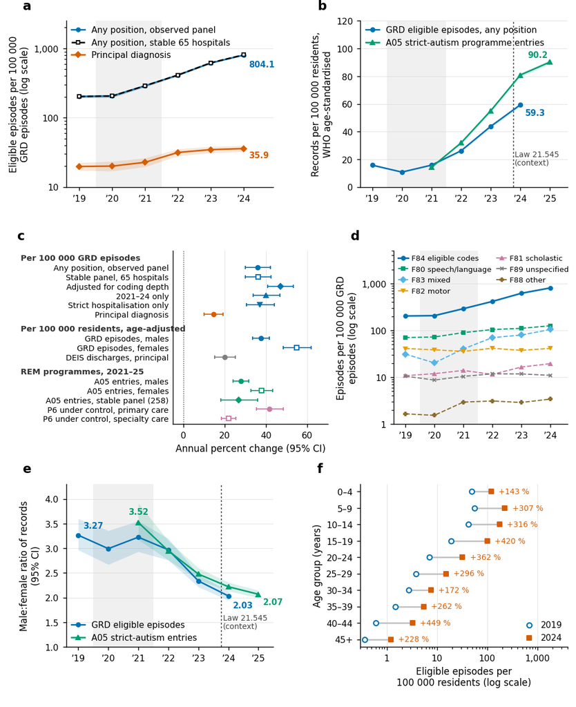

**Figure 1. Hospital recording of autism in Chile, 2019–2025: magnitude, robustness and who is recorded.** (a) Episodes with an eligible F84 code in any diagnostic position, and with the code as principal diagnosis, per 100 000 GRD episodes of the same year and panel; the observed panel contains 65, 65, 65, 65, 68 and 72 hospitals and the stable panel the 65 hospitals present in every year (logarithmic scale). (b) The same eligible episodes and strict-autism A05 programme entries (code 05990022, 2021–2025) per 100 000 residents, directly standardised to the WHO world age distribution; denominators are INE resident populations, base 2017. (c) Annual percent change from quasi-Poisson models with 95% Wald intervals: per 100 000 GRD episodes, per 100 000 residents with age adjustment, and for REM programme series (A05 entries per resident by sex and in the stable panel of 258 establishments; P6 people under control in December). (d) Episodes with a code from each category of the F80–F89 block per 100 000 GRD episodes of the observed panel; the eligible F84 line excludes F84.2, the other categories count the full three-character category. (e) Male-to-female ratio of eligible GRD episodes and of A05 entries with exact conditional-binomial 95% intervals, assuming independent records. (f) Eligible episodes per 100 000 residents by age group in 2019 and 2024, both sexes, logarithmic scale; labels give the percentage change. Bands and bars are exact Poisson or Fay–Feuer 95% intervals conditional on observed denominators; they do not account for repeated episodes of the same person. Grey shading marks 2020–2021; the dotted line marks the publication of Law 21.545 (March 2023) as context, not as an intervention. Abbreviations: GRD=diagnosis-related groups; REM=Monthly Statistical Summaries; A05=REM mental-health entry module; P6=REM population-under-control module; INE=National Statistics Institute; CI=confidence interval; P6=REM mental-health follow-up module; DEIS=Department of Health Statistics and Information; WHO=World Health Organization.

Plate files (175 mm, 300 dpi): PNG · SVG · PDF

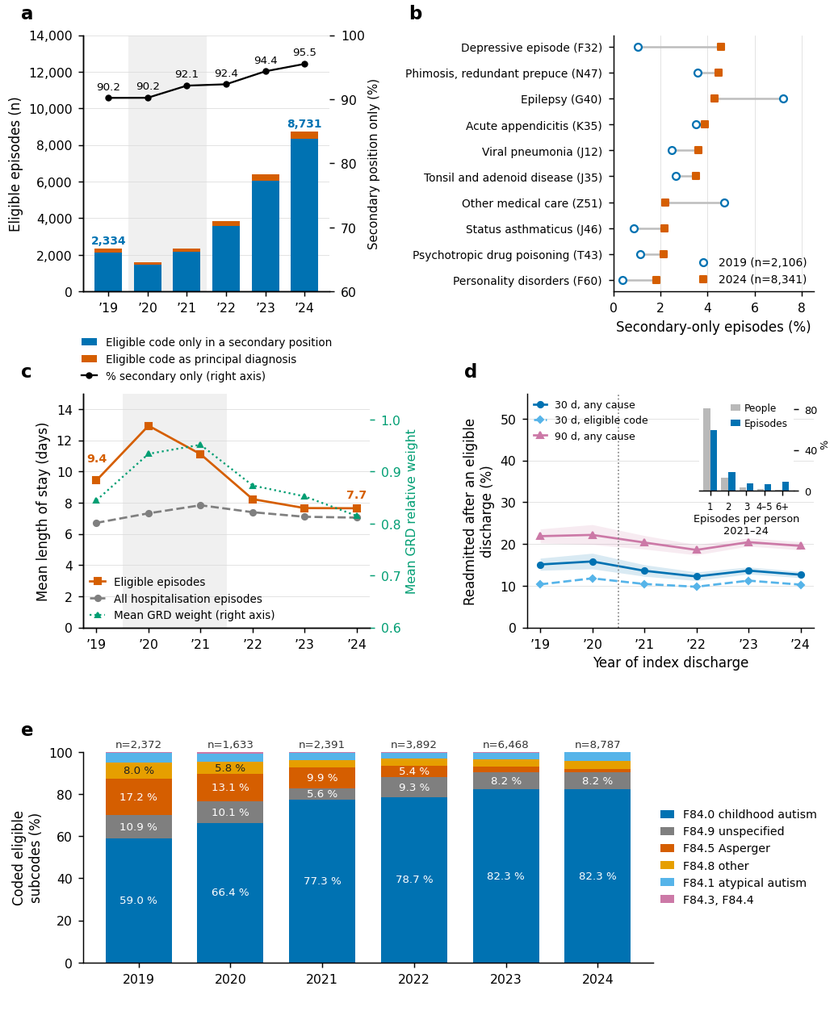

**Figure 2. Clinical profile of hospital episodes with an eligible autism code, Chile, 2019–2024.** (a) Eligible episodes by diagnostic position of the code (principal, or secondary positions only) and, on the right axis, the percentage with the code only in a secondary position. (b) Principal three-character ICD-10 categories among episodes eligible only through secondary coding, 2019 and 2024; the ten most frequent 2024 categories are retained in both years and denominators are 2 106 and 8 341 episodes. (c) Mean length of stay of eligible hospitalisation episodes and of all hospitalisation episodes of the same panel, and, on the right axis, the mean relative weight of the diagnosis-related group of eligible episodes; descriptive means without standardisation. (d) Readmission for any cause within 30 and 90 days of an eligible discharge, and readmission with an eligible code within 30 days, with exact binomial 95% bands; identifiers are not linked across the 2020–2021 format change (dotted line). Inset: distribution of eligible episodes per identifier in 2021–2024 as a percentage of people and of episodes. (e) Composition of the coded eligible F84 subcodes in any position as a percentage of all eligible subcodes coded in the year; an episode can carry more than one subcode, so n exceeds the episode count, and F84.2 never confers eligibility. Observed proportions have no sampling intervals and are not clinically validated comorbidity estimates. Grey shading marks 2020–2021. Abbreviations: GRD=diagnosis-related groups; ICD-10=International Classification of Diseases, tenth revision.

Plate files (175 mm, 300 dpi): PNG · SVG · PDF

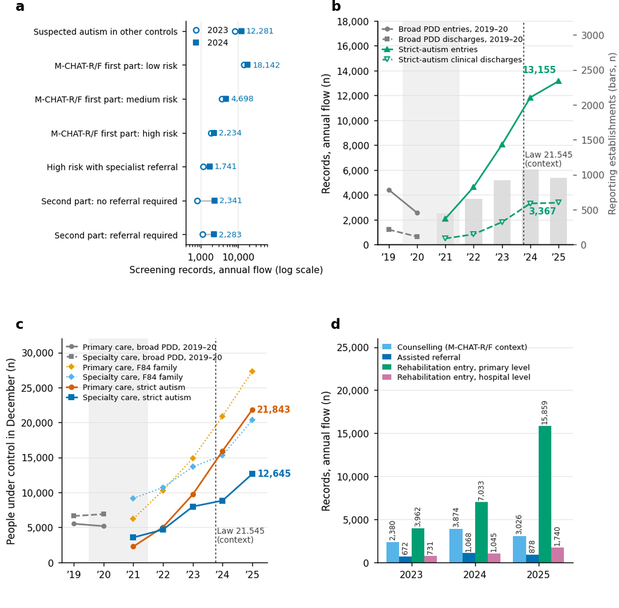

**Figure 3. The community care pathway recorded in the REM: screening, programme entry, follow-up and rehabilitation, 2019–2025.** (a) A03 screening records in the M-CHAT-R/F era, annual flows in 2023 and 2024 (logarithmic scale); the earlier M-CHAT items and the 2024–2025 redesign are shown in figure S4. (b) A05 strict-autism programme entries (05990022) and clinical discharges (05990027), 2021–2025, with the broad pervasive-developmental-disorder codes of 2019–2020 shown separately because of the definition break; bars give the number of establishments reporting entries. (c) People under control in December in primary and specialty care: strict-autism codes (P6241010, P6241060), the F84 family excluding Rett syndrome, and the broad 2019–2020 codes, which are not connected across the break. (d) Counselling and assisted referral in the screening context (A27) and entries to primary-level and hospital-level rehabilitation (A28), 2023–2025, with counts above each bar. Flows count records during the year and stocks count people at a reporting cut; none counts unique people across establishments or years, and the items cannot be linked into an individual cascade. Absent rows are not zeros. Grey shading marks 2020–2021; the dotted line marks the publication of Law 21.545 (March 2023) as context. Abbreviations: REM=Monthly Statistical Summaries; APS=primary health care; M-CHAT-R/F=Modified Checklist for Autism in Toddlers, Revised with Follow-Up; A03, A05, A27, A28, P6=REM modules; PDD=pervasive developmental disorder; A05=REM mental-health entry module; P6=REM mental-health follow-up module; A28=REM rehabilitation module; A03=REM assessment-scale module; A27=REM health-education module; PDD=pervasive developmental disorders; M-CHAT=Modified Checklist for Autism in Toddlers.

Plate files (175 mm, 300 dpi): PNG · SVG · PDF

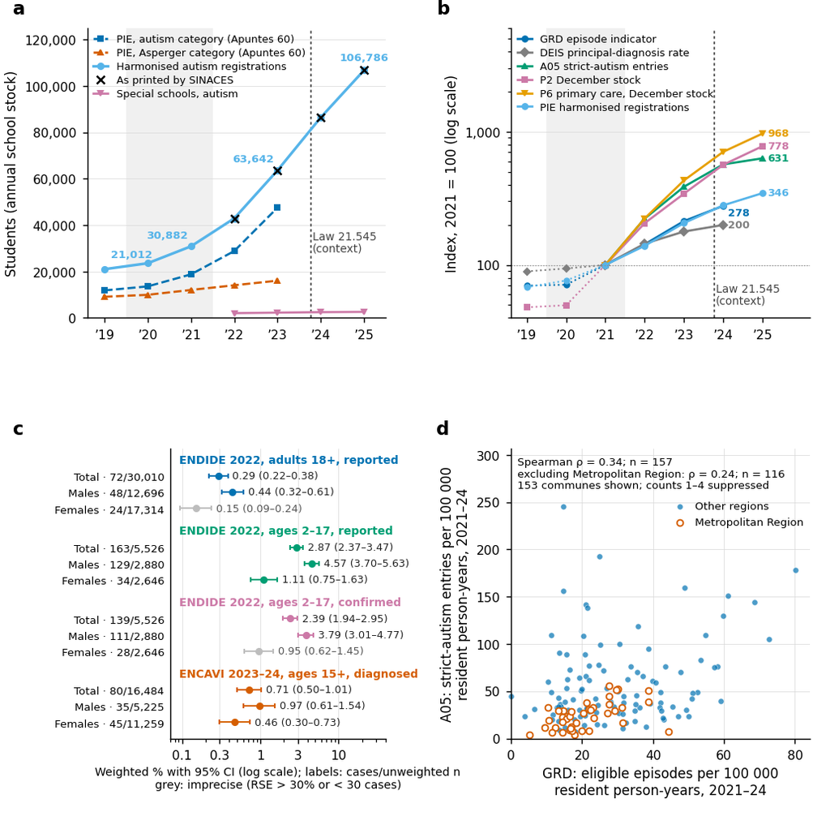

**Figure 4. Convergence across health and education systems, population-survey context and territorial alignment.** (a) Students with autism registered in the School Integration Programme: the historical autism and Asperger categories and their harmonised sum (Apuntes 60, 2019–2023), the totals printed by SINACES (2022–2025) and autism special schools; annual school stocks. (b) Each source relative to its own 2021 value (log scale): GRD eligible episodes per 100 000 GRD episodes, DEIS principal-diagnosis discharges per 100 000 discharges, A05 strict-autism entries, the P2 December stock (ages 0–19), P6 primary-care people under control and harmonised PIE registrations; dotted segments precede the first common year. (c) Population-survey estimates of reported or diagnosed autism, weighted percentages with Taylor-linearised 95% intervals on a logarithmic scale, by sex; labels give unweighted cases over the domain sample; grey estimates are imprecise. (d) Communes in the common 2021–2024 window: GRD eligible episodes located by residence against A05 strict-autism entries located by the reporting establishment, both per 100 000 resident person-years; communes with positive counts of 1–4 in either source are not displayed, and Metropolitan Region communes are marked. Spearman coefficients are descriptive, without spatially adjusted intervals. Equal indices do not imply equal levels or coverage; the sources are not linked at the individual level, the surveys are not used to validate records, and the dotted line marks the publication of Law 21.545 as context. Abbreviations: PIE=School Integration Programme; SINACES=National System of Certification of Special Educational Needs; GRD=diagnosis-related groups; DEIS=Department of Health Statistics and Information; REM=Monthly Statistical Summaries; A05, P2, P6=REM modules; ENDIDE=National Disability and Dependency Survey; ENCAVI=National Quality of Life and Health Survey; CI=confidence interval; A05=REM mental-health entry module; P2=REM child/adolescent special-health-needs follow-up module; P6=REM mental-health follow-up module; SINACES=National Higher Education Quality Assurance System; RSE=relative standard error.

Plate files (175 mm, 300 dpi): PNG · SVG · PDF